# Game Theory: Parrondos Paradox

We import the libraries

```python
import numpy as np
import matplotlib.pylab as plt
```

We define the first game

```python
def GameA(Money2):
    Money=Money2.copy()
    eps=0.005
    pg=0.5-eps
    rga=np.random.random()
    if(rga<pg):
        Money=np.append(Money,Money[-1]+1)
    else:
        Money=np.append(Money,Money[-1]-1)
    return Money
```

We define the second game

```python
def GameB(Money2):
    Money=Money2.copy()
    eps=0.005
    p2=0.9+eps
    p3=0.25+eps
    M=Money[-1]
    ra=np.random.random()
    if (M%3==0):
        if (ra<p2):
            Money=np.append(Money,M-1)
        else:
            Money=np.append(Money,M+1)
    else:
        if(ra<p3):
            Money=np.append(Money,M-1)
        else:
            Money=np.append(Money,M+1)
    return Money
```

Let us explore how the behavior of the second game is

```python
moneyB=np.array([1001])
for i in range(1000):
    r=np.random.random()
    moneyB=GameB(moneyB)
print(moneyB)
```

```
[1001 1002 1001 ...  999  998  997]
```

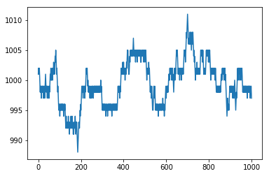

```python
plt.plot(moneyB,label='B')
```

As it is not clear, let us see the averages, so we will have 3 arrays, one for game A, another for game 2, and the third one for the combination

```python
averaging=5000
N=200
aveA=np.zeros(N)
aveB=np.zeros(N)
ave=np.zeros(N)
for j in range(averaging):
    moneyA=np.array([0])
    moneyB=np.array([0])
    money=np.array([0])
    for i in range(N-1):
        r=np.random.random()
        moneyA=GameA(moneyA)
        moneyB=GameB(moneyB)

        if r<0.5:
            money=GameA(money)
        else:
            money=GameB(money)
    aveA+=moneyA
    aveB+=moneyB
    ave+=money
aveA=aveA/averaging
aveB=aveB/averaging
ave=ave/averaging
```

And the plot of the averages is,

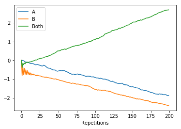

```python
plt.xlabel("Repetitions")
plt.plot(aveA,label='A')
plt.plot(aveB,label='B')
plt.plot(ave,label='Both')
plt.legend()
```

### Conclusions

As the plot shows that the game a and the game b goes down, it means that are losing games, in contrast to the green one that, on averages, is a wining strategy.

# Random Numbers: Accepting or Rejecting

We define the gaussian we want to sample

```python
def gauss(x):
    return np.exp(-0.5*x**2)
```

We repeat the same procedure until 50000 are acepted

```python
data=np.array([])
while len(data)<50000:
    x=np.random.random()*6-3
    y=np.random.random()
    if y<gauss(x):
        data=np.append(data,x)
```

we plot the results

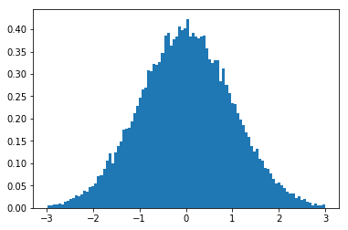

```python
hist=plt.hist(data,density=True,bins=100)
```

We separate the bins and amplitude information

```python
x=(hist[1][:-1]+hist[1][1:])/2
y=hist[0]
```

We import the fit function and define the model for the fit

```python
from scipy.optimize import curve_fit
def model(x,a):
    return a*gauss(x)
```

We fit

```python
popt,pcov=curve_fit(model,x,y)
```

we plot the final results.

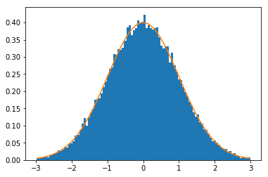

```python
plt.hist(data,density=True,bins=100)
plt.plot(x,model(x,*popt))
```

The percentage error of the fit is

```python
print(pcov.diagonal()**0.5/popt)
```

```
[0.00381698]
```

So, our model seems to be good to generate these kind of points.

# Random Numbers on Sphere

If one generates the random numbers (on the apropiate domains),

```python
theta=np.random.random(1000)*np.pi
phi=np.random.random(1000)*2*np.pi
r=1
```

We get the following plot

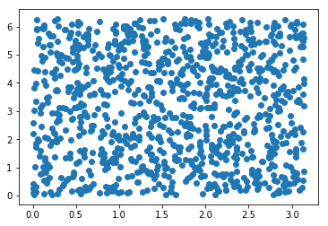

```python
plt.scatter(theta,phi)
```

But, it does not represent the sphere, so let us go to the cartesian coordinates

```python
x,y,z=r*np.cos(phi)*np.sin(theta),r*np.sin(phi)*np.sin(theta),r*np.cos(theta)
```

So when we plot a projection of these points

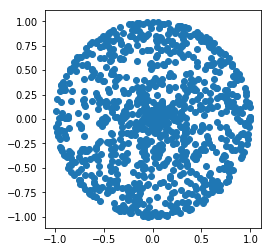

```python
fig=plt.figure()
ax=fig.add_subplot(111)
ax.set_aspect("equal")
ax.scatter(x,y)
```

Or other

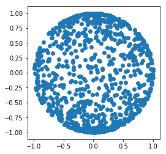

```python
fig=plt.figure()
ax=fig.add_subplot(111)
ax.set_aspect("equal")
ax.scatter(x,z)
```

Or other

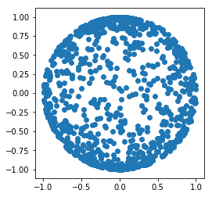

```python
fig=plt.figure()
ax=fig.add_subplot(111)
ax.set_aspect("equal")
ax.scatter(y,z)
```

We do not have the same results, and if they are uniform we shall not expect to have preferred directions,

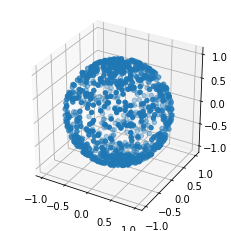

```python
from mpl_toolkits.mplot3d import Axes3D
fig = plt.figure()
ax = fig.add_subplot(111, projection='3d')
ax.set_aspect('equal')
ax.scatter(x,y,z)
```

## Gaussian

```python
N=1000
x=np.random.normal(0,1,N)
y=np.random.normal(0,1,N)
z=np.random.normal(0,1,N)
norm=np.sqrt(x**2.+y**2.+z**2.)
x/=norm
y/=norm
z/=norm
```

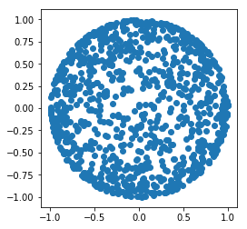

```python
fig=plt.figure()
ax=fig.add_subplot(111)
ax.set_aspect("equal")
ax.scatter(x,y)
```

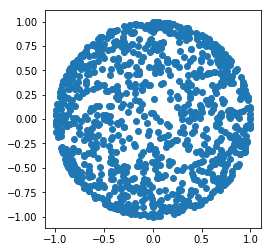

```python
fig=plt.figure()
ax=fig.add_subplot(111)
ax.set_aspect("equal")
ax.scatter(x,z)
```

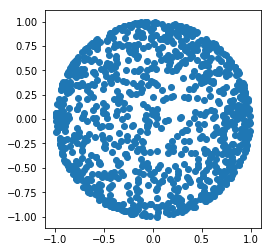

```python
fig=plt.figure()
ax=fig.add_subplot(111)
ax.set_aspect("equal")
ax.scatter(y,z)
```

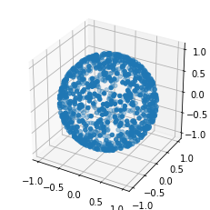

```python
fig=plt.figure()
ax=fig.add_subplot(111,projection='3d')
ax.set_aspect("equal")
ax.scatter(x,y,z)
```

## Jacobian

```python
N=1000
phi=np.random.random(N)*2*np.pi
theta=np.arccos(2*np.random.random(N)-1)

r=1

x,y,z=r*np.cos(phi)*np.sin(theta),r*np.sin(phi)*np.sin(theta),r*np.cos(theta)
```

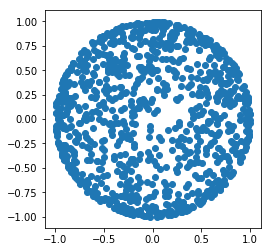

```python
fig=plt.figure()
ax=fig.add_subplot(111)
ax.set_aspect("equal")
ax.scatter(x,y)
```

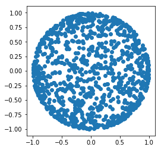

```python
fig=plt.figure()
ax=fig.add_subplot(111)
ax.set_aspect("equal")
ax.scatter(x,z)
```

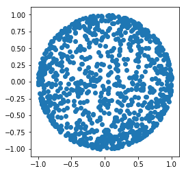

```python
fig=plt.figure()
ax=fig.add_subplot(111)
ax.set_aspect("equal")
ax.scatter(y,z)
```

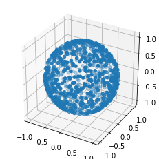

```python
fig=plt.figure()
ax=fig.add_subplot(111,projection='3d')
ax.set_aspect("equal")
ax.scatter(x,y,z)
```

# Metropolis Hastings

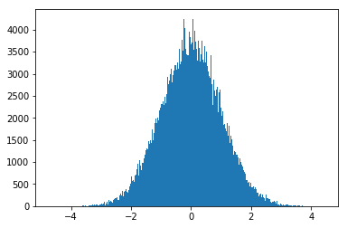

```python
mu,sig,N = 0,1,1000000

def q(x):
    return (1./(np.sqrt(2*np.pi*sig**2)))*(np.exp(-((x-mu)**2)/(2*sig**2)))

def metropolis(N):
    r = 0
    p = q(r)
    points = []

    for i in range(N):
        rn =np.random.uniform(-10,10)
        pn = q(rn)

        if pn >= p:
            p = pn
            r = rn
        else:
            u = np.random.rand()
            if u < pn/p:
                p = pn
                r = rn
        points.append(r)
    points = np.array(points)
    return points


pts=metropolis(N)
fig = plt.figure()
ax = fig.add_subplot(111)
ax.hist(pts, bins=1000);
```

# Single Random Walk and Rolling Average

```python
x=np.random.normal(0,1,100)

def cumulative_sum(x):
    cum=np.array([x[0]])
    for i in range(1,len(x)):
        cum=np.append(cum,cum[i-1]+x[i])
    return cum
```

```python
test=cumulative_sum(x)
x=x.cumsum()
```

```python
print(test-x)
```

```
[0. 0. 0. 0. 0. 0. 0. 0. 0. 0. 0. 0. 0. 0. 0. 0. 0. 0. 0. 0. 0. 0. 0. 0.
 0. 0. 0. 0. 0. 0. 0. 0. 0. 0. 0. 0. 0. 0. 0. 0. 0. 0. 0. 0. 0. 0. 0. 0.
 0. 0. 0. 0. 0. 0. 0. 0. 0. 0. 0. 0. 0. 0. 0. 0. 0. 0. 0. 0. 0. 0. 0. 0.
 0. 0. 0. 0. 0. 0. 0. 0. 0. 0. 0. 0. 0. 0. 0. 0. 0. 0. 0. 0. 0. 0. 0. 0.
 0. 0. 0. 0.]
```

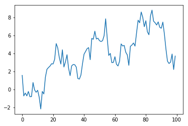

```python
plt.plot(x)
```

```python
lin=np.linspace(0,100,100)
noi=2*np.sin(lin/5)+x
```

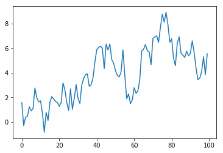

```python
plt.plot(noi)
```

```python
def roll(x,w):
    rolling=np.array([])
    for i in range(w,len(x)):
        rolling=np.append(rolling,x[i-w:i].mean())
    return rolling
```

```python
rolling=roll(noi,5)
```

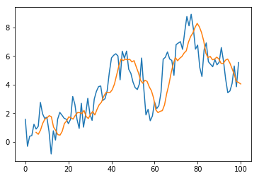

```python
plt.plot(noi)
plt.plot(np.linspace(5,100,len(rolling)),rolling)
```

# Random Walks: DIffusion

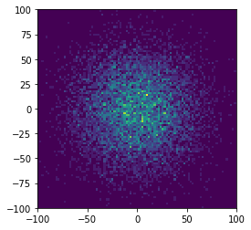

```python
number=10000
steps=1000
x=np.zeros(number)
y=np.zeros(number)
stdx=[]
stdy=[]

for step in range(steps):
    x+=np.random.normal(0,1,number)
    y+=np.random.normal(0,1,number)
    stdx.append(np.var(x)**0.5)
    stdy.append(np.var(y)**0.5)

fig=plt.figure()
ax=fig.add_subplot(111)
ax.set_aspect("equal")
#ax.hexbin(x,y,gridsize=30);
ax.hist2d(x,y,bins=np.linspace(-100,100,100));
#plt.savefig("plots/"+str(step)+".png")
#plt.close()
```

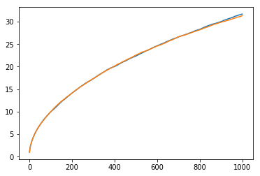

```python
plt.plot(stdx)
plt.plot(stdy)
```

# Information Theory: Entropy

```python
from scipy.stats import entropy
print(entropy(hist[0]))
```

```
4.219687484693533
```

```python
def entropy2(P):
    ent=0.
    P=P/np.sum(P)
    for pi in P:
        if pi!=0:
            ent-=pi*np.log(pi)
    return ent
```

```
100.00012015338218
4.605125611116569
4.6051256111165655
```

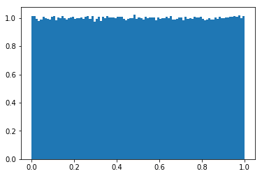

```python
x=np.random.random(1000000)
hist=plt.hist(x,density=True,bins=100);
print(hist[0].sum())
print(entropy(hist[0]))
print(entropy2(hist[0]))
```

```
3.7332430659669873
3.7332430659669864
```

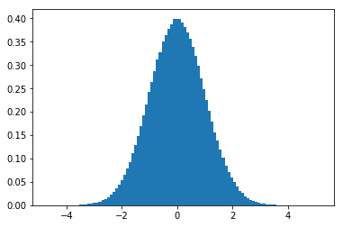

```python
x=np.random.normal(0,1,1000000)
hist=plt.hist(x,density=True,bins=100);

print(entropy(hist[0]))
print(entropy2(hist[0]))
```

```
3.736089406862346
3.7360894068623454
```

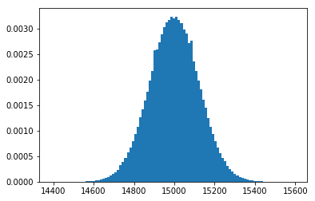

```python
x=np.random.poisson(15000,1000000)
hist=plt.hist(x,density=True,bins=100);

print(entropy(hist[0]))
print(entropy2(hist[0]))
```

The distribution with the largest entropy is the uniform distribution